# PH1976 Project: Predicting Parkinson’s Disease for Patients Using Voice Recording

Erin S. King

2023-04-10

# 1 Introduction

The following analysis in this PH1976 project is to demonstrate the tools examined in this course for data categorization, regression, and prediction. The project’s aim is to predict Parkinson’s disease (PD) using the extracted features from the voice recording of patients. For each individual, three recording samples were collected. The [data and corresponding analysis](https://doi.org/10.1016/j.asoc.2018.10.022) is provided by @Sakar in their seminal research on implementing tunable Q-factor wavelet transforms in conjunction with existing data prediction methods. The methods found in this study serve as a roadmap for this project and inform the methods chosen for categorization and prediction.

## 1.1 Definition

Parkinson’s disease (PD) is a progressive neurodegenerative disorder. To accurately detect the disease in the early stage, many telediagnosis and telemonitoring systems have recently been proposed. Since vocal problem is one of the most important symptoms which can be seen in the earlier stage of PD patients, vocal disorders- based systems become popular in PD diagnosis and monitoring. In these systems, various speech signal processing algorithms have been used to extract clinically useful information for PD assessment, and the calculated features are fed to different learning algorithms to make reliable decisions. PD telemedicine studies showed that the choice of extracted features and learning algorithms directly influences the accuracy and reliability of distinguishing PD patients.

## 1.2 Data

In this study, Sakar et. al collected the voice recordings of 252 subjects including PD patients and healthy individuals. They gathered three recording samples from each subject and extracted seven feature subsets from the recording samples. The feature subsets were baseline features, intensity-based features, bandwidth and formant features, vocal fold features, Mel Frequency Cepstral Coefficients (MFCC), wavelet transform based features (WT) and tunable Q-factor wavelet transform based features (TQWT).

## 1.4 Study Population

The dataset includes PD patients with age ranging from 33 to 87 (65.1 ± 10.9) and healthy individuals with age ranging from 41 to 82 (61.1 ± 8.9). Each patient has three voice recording samples, with 7 aforementioned feature subsets. Each feature subset contains several features.

# 2 Methods

## 2.1 Preprocessing and Standardization

Instead of using the LOOCV method outlined in the paper, we have decided to break the training dataset into a 90/10 split, where 90% of the data will be used to train, and 10% of the data will be used to check accuracy of the model. The best model for each subset will be selected based on these results.

For ease of analysis, the ensemble data set (both training and test) are broken into the following sub feature categories:

- Baseline Features
- Time Frequency Features
  - Intensity based
  - Formant and Bandwidth based
- Vocal Fold Features
- Mel Frequency Cepstral Coefficients (MFCC)
- Wavelet Transform-based Features
- Tunable Q-Factor Wavelet Transform-based Features (TQWT)

Overall, these seven sub features were used to inform the machine learning model and perform predictions on the test set.

The authors considered using PCA analysis to perform data reduction and to minimize multi-colinearity, but this ultimately was decided against for clarity. Due to the inherent complexity that comes along with transforming the data set with PCA, the authors opted to use the standardization method above, and implement a subsequent Random Forest (Boruta) factor selection method following the standardization.

[output not shown]

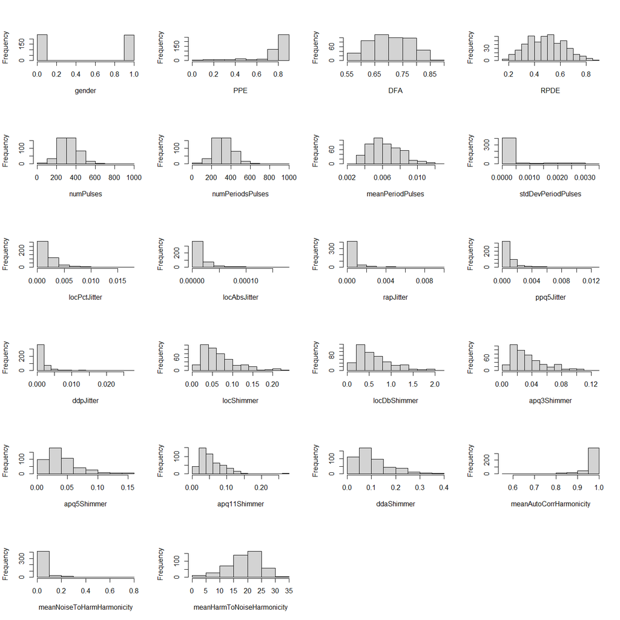

Figure 2.1: center

[output not shown]

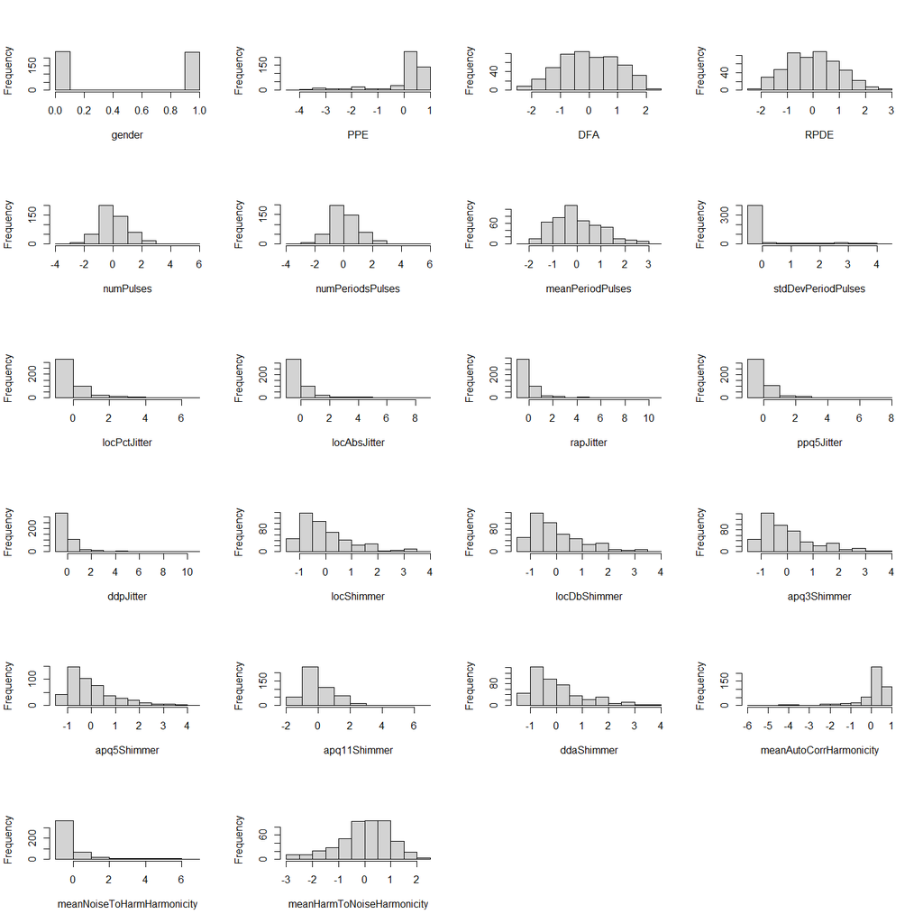

Figure 2.2: center

[output not shown]

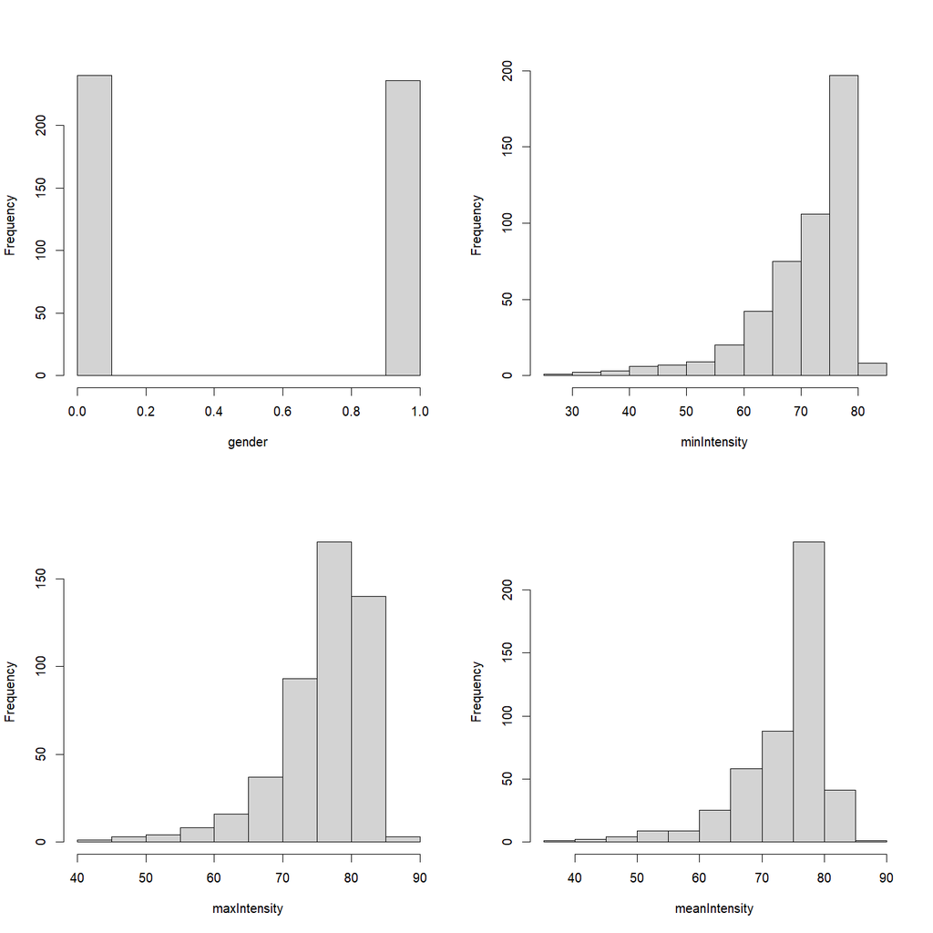

Figure 2.3: center

[output not shown]

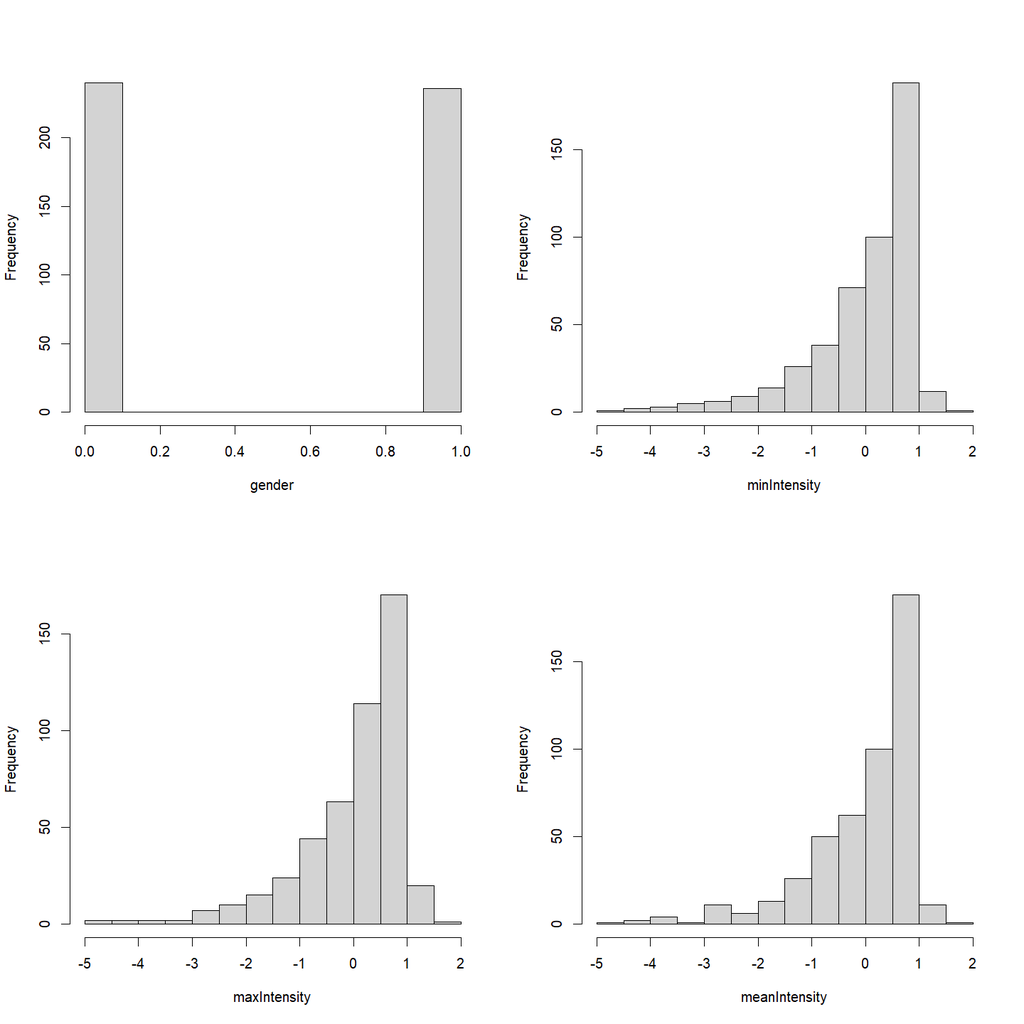

Figure 2.4: center

[output not shown]

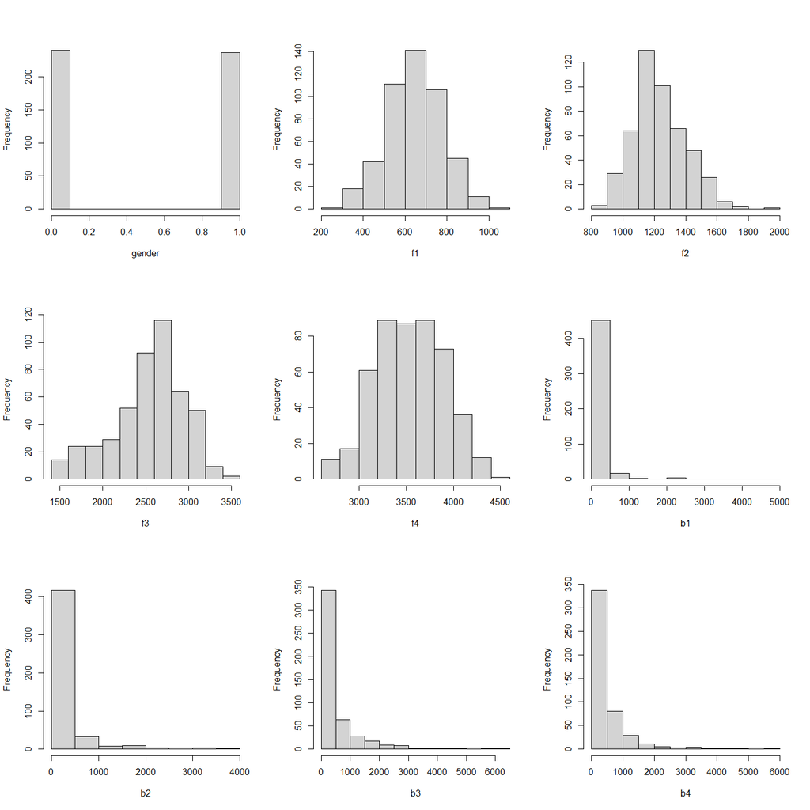

Figure 2.5: center

[output not shown]

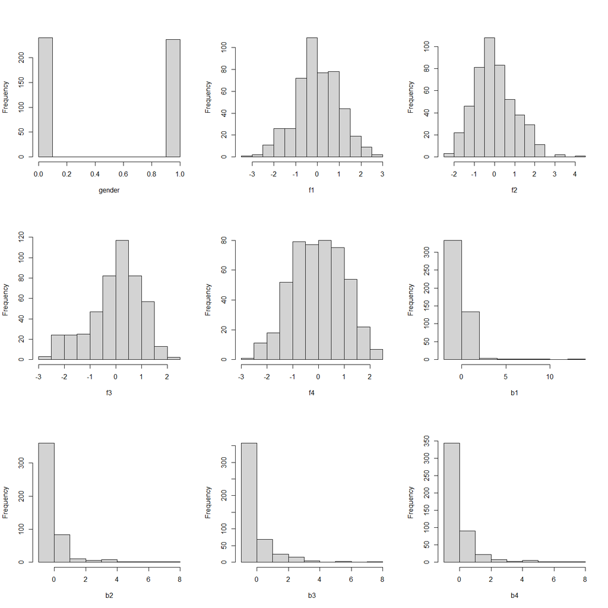

Figure 2.6: center

[output not shown]

# 3 Results

## 3.1 Feature Selection

Per the **Sakar et al** paper, minimum redundancy-maximum relevance based filter feature selection methods are ideal for determining effective features. The advantage of this is two-fold: 1. It reduces the high dimensionality of the data set. 2. It maximizes the joint dependency of the data set. This strategy is used frequenty in machine learning and regression applications, and as such, will be used in this analysis. The **Boruta** package in RStudio will be used for this purpose, and utilizes Random Forest to perform a top-down search on the corresponding data frame to determine relevant features.

[output not shown]

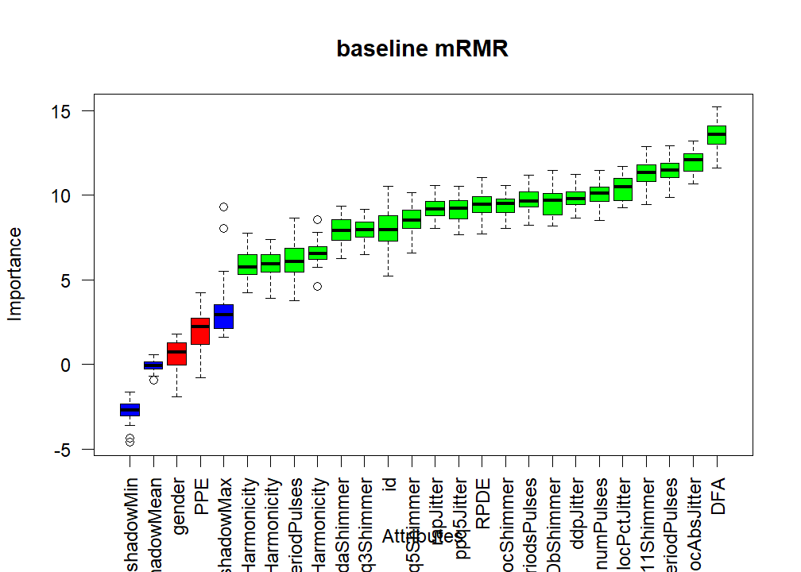

Figure 3.1: center

[output not shown]

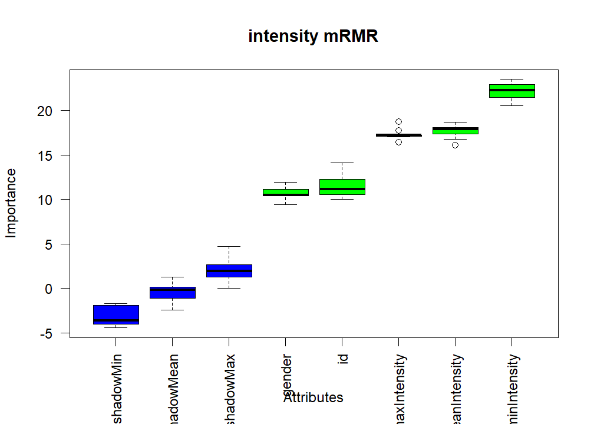

Figure 3.2: center

[output not shown]

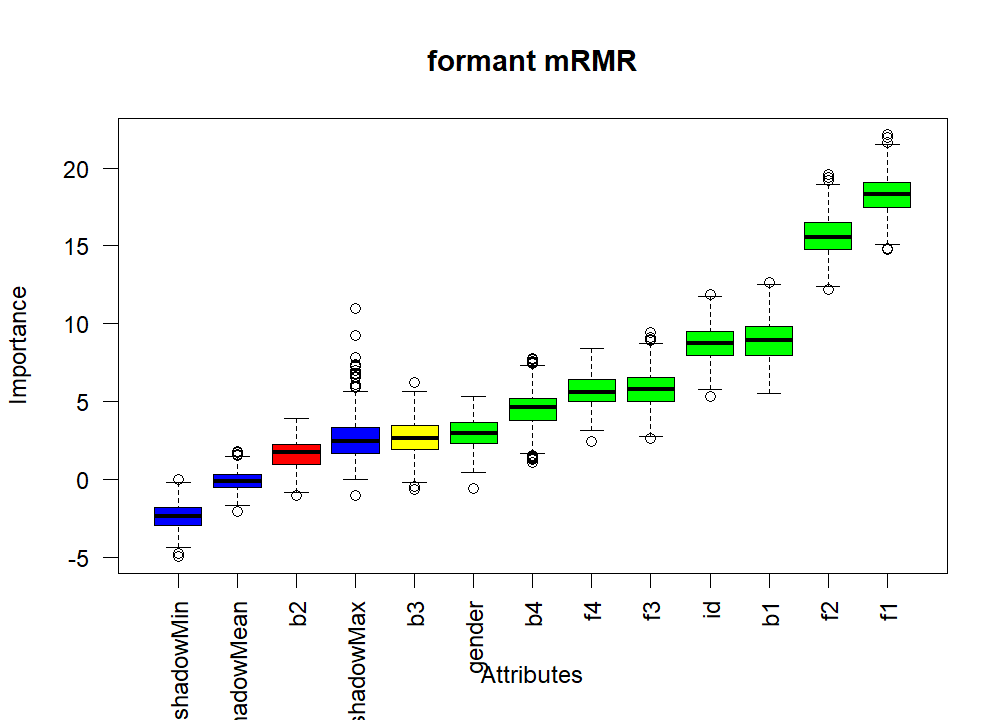

Figure 3.3: center

[output not shown]

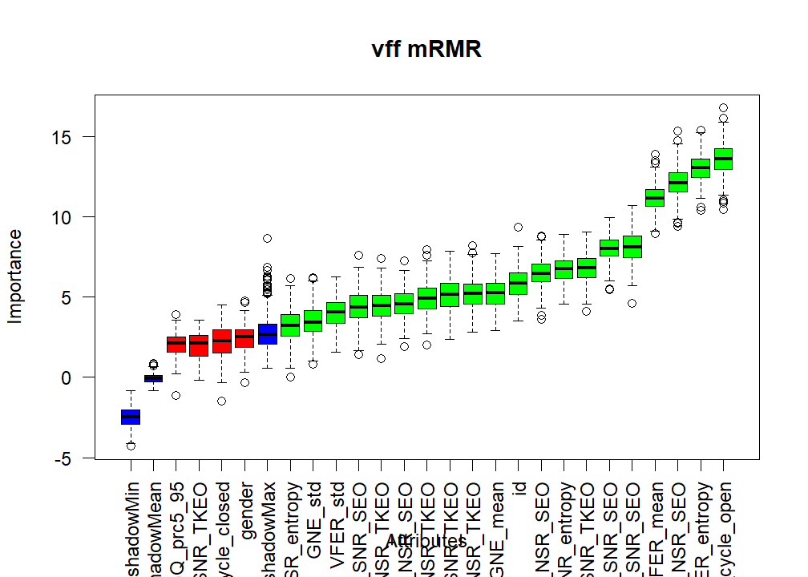

Figure 3.4: center

[output not shown]

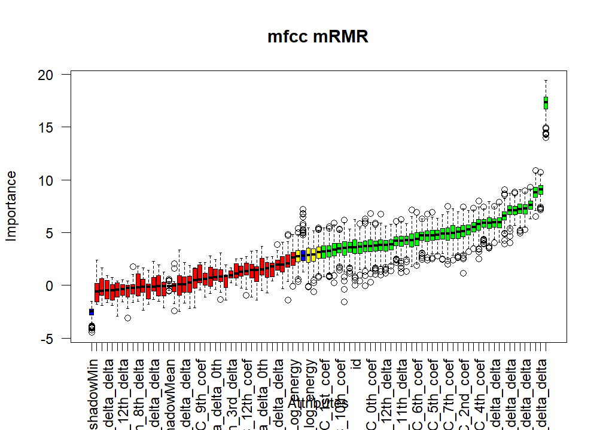

Figure 3.5: center

[output not shown]

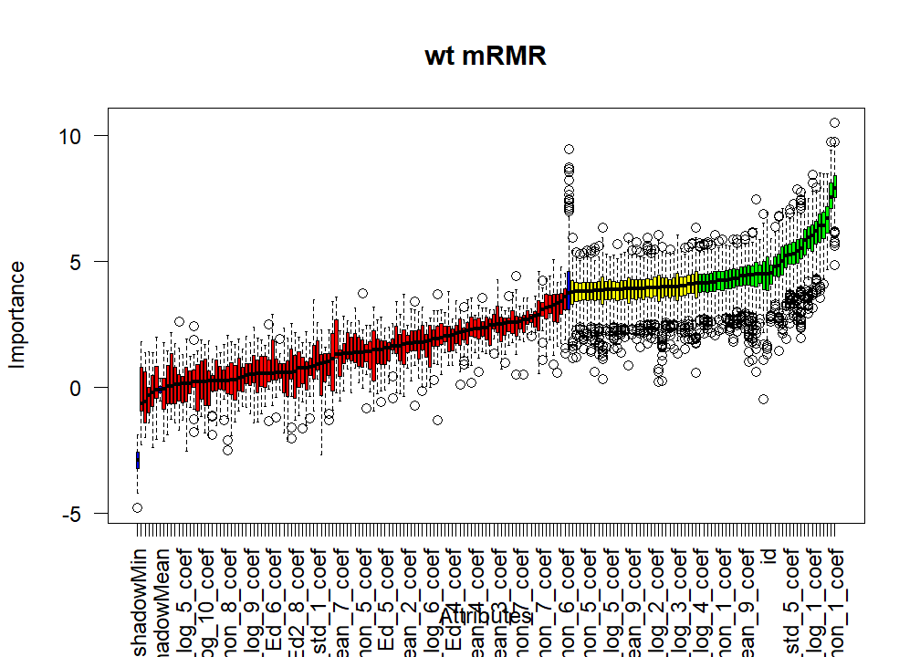

Figure 3.6: center

[output not shown]

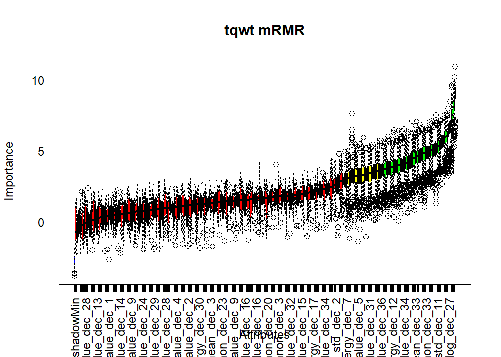

Figure 3.7: center

[output not shown]

Following this initial assessment, chosen variables are selected for regression by using **getNonRejectedFormula()**. This collapses any variables left as **Tentative** factors into either Accepted or Rejected.

The following factors were found to be important to the model:

```
  [1] "class"                          "id"
  [3] "DFA"                            "RPDE"
  [5] "numPulses"                      "numPeriodsPulses"
  [7] "meanPeriodPulses"               "stdDevPeriodPulses"
  [9] "locPctJitter"                   "locAbsJitter"
 [11] "rapJitter"                      "ppq5Jitter"
 [13] "ddpJitter"                      "locShimmer"
 [15] "locDbShimmer"                   "apq3Shimmer"
 [17] "apq5Shimmer"                    "apq11Shimmer"
 [19] "ddaShimmer"                     "meanAutoCorrHarmonicity"
 [21] "meanNoiseToHarmHarmonicity"     "meanHarmToNoiseHarmonicity"
 [23] "gender"                         "minIntensity"
 [25] "maxIntensity"                   "meanIntensity"
 [27] "f1"                             "f2"
 [29] "f3"                             "f4"
```

[output cut: 128 more lines]

## 3.2 Model Selection

For this analysis it required the use of the **caret**, **randomForest**, **e1071**, **nnet**, **kernlab**, and **naivebayes** libraries.

The following results were found for each of the sub features. A comparative bar chart for each of the sub features is also included.

```
Best model for baseline is KNN with an accuracy of 0.75
Best model for intensity is Random Forest with an accuracy of 0.7307692
Best model for formant is Multilayer Perceptron with an accuracy of 0.6923077
Best model for vff is Random Forest with an accuracy of 0.7115385
Best model for mfcc is Multilayer Perceptron with an accuracy of 0.7884615
Best model for wt is Random Forest with an accuracy of 0.7884615
Best model for tqwt is Random Forest with an accuracy of 0.8653846
```

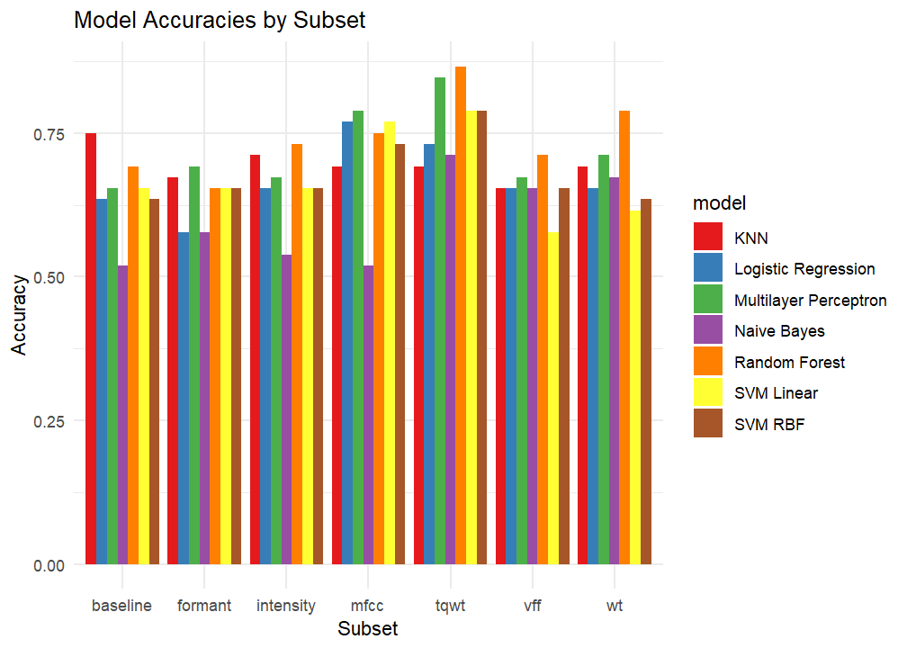

Figure 3.8: center

At this point, we have enough data to make an ensemble predictive model, such that the best performing model for each subfeature can be used.

# 4 Model Output